# Human Manipulation of Plants

## Humans have manipulated plants since the ‘dawn of civilization’

- **Ancient Biotechnology (pre 1800)**
  - domestication of crops
  - yeast for fermentation and leavened bread
  - molds to saccharify rice
- **Classical Biotechnology (1800-1945)**
  - crossbreeding of cotton (100s of varieties)
  - first corn hybrid invented, then commercialized
  - Haber Bosch process (commerical fertilizer)
- **Modern Biotechnology (1945 - present)**
  - first genetically engineered plant (1981)
  - pest-resistant corn (B<sub>t</sub>) produced
  - 1993 GM foods declared ’not dangerous”
  - UN endorses biotech crops
  - epigenetic cotton (not flowering restriction)
  - disease resistant rice

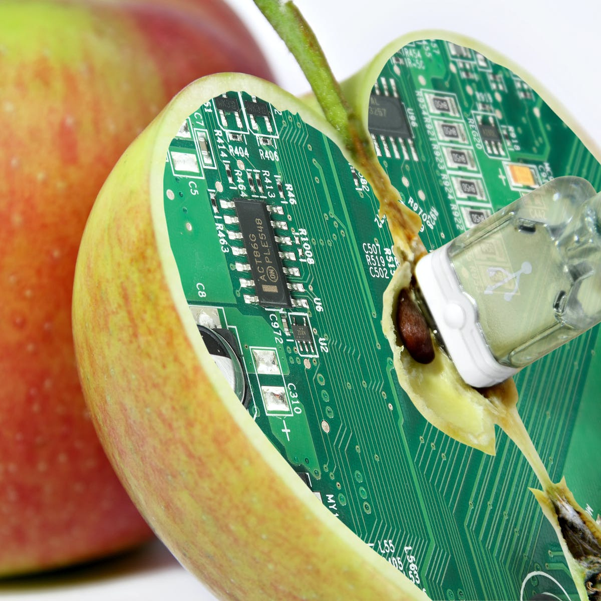

## Intent Behind Plant Biotechnology

- **Identify promising traits and breed/engineer them into crop plants**
  - intent the same for traditional plant breeding
- **Introduce herbicide resistance into crop varieties with large yields or vice-versa**
- **Speed matters! Current biotechnology works faster than traditional breeding**

**70-40 million people are expected to be added to the world’s population each year for the next 30 years. Without biotechnology, will we be able to increase the availability of affordable basic food?**

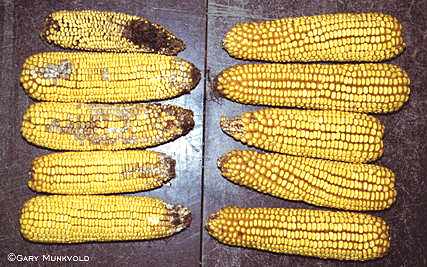

## Cell and Tissue Culture

[figure not shown]

- **Growing plants from single cells has major applications**
  - ‘clones’
- **Plants are easy to clone from single cells because many cells can revert to a flexible starter state and then grow into an entire new plant with simple hormone cues**
- **Viruses are less common in stem tissues…**
- **Rates of mutations appear greater in cell cultures**
  - study: 13 unique traits from 240 tomato plantlets
  - avenue to screen for new traits

## Molecular Plant Breeding

- **Artificial selection (Mendel) can produce a desired trait**
  - but takes many generations
  - traits like resistance are not ‘visible’
- **Marker-assisted selection: screening young seedlings for a specific DNA sequence**
  - large fruit size
  - disease resistance
- **Possible because of the ↑ # of plant genomes**
  - high throughput growth environments
  - gene editing and genetic engineering

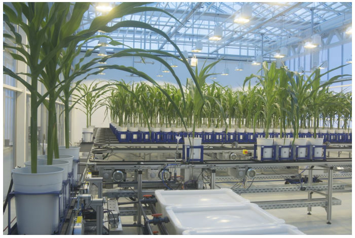

## Transgenic Plants

- **Molecular biology allows breeders to harness the ’Central Dogma”**
  - DNA instructions turned into useful products
- **Genetic engineering allows transfer of genes across species**
  - *transgenic plants*
  - not possible with traditional breeding
- **Foreign genes inserted with bacterial plasmid**
  - T1 plasmid causes tumor growth, tumor genes suppressed, plasmid enters cell nucleus safely and incorporates new target genes
- **75% of processed foods in US contain ingredients from GM plants**
  - ~90% of GM staple crops are transgenic

[figure not shown]

## Case Study: Herbicide resistance

- **Weed control is key for increasing crop yield**
  - competition for light, water & nutrients
  - chemical herbicides are widespread
- **Sustainable no-till agriculture may still need herbicides (at larger scales)**
- **Glyphosate is the most widely used herbicide in agriculture, globally**
- **Bacterial gene with glyphosate resistance introduced to various crop plants**
  - allows use of 1 broad spectrum herbicide
  - 88% of transgenic crops = herbicide resistance

[figure not shown]

## Against the Grain

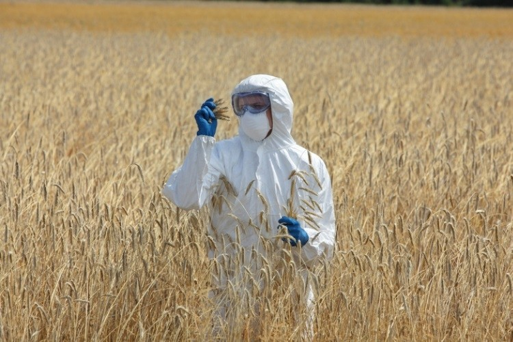

## Case study: Insect resistance

- **Bacillus thuringiensis = soil bacterium that produces proteins with insecticide properties**
  - 1,000+ strains isolated
  - 200 different useful proteins
- **Bt crops commercially planted in 1996**
  - corn, cotton & potatoes
  - 85+% of US corn acres now express Bt toxins
- **Bt crops are believed to save 50-70% of costs of insecticides**
  - also avoids indirect environmental damage
  - Bt toxins not harmful to animals

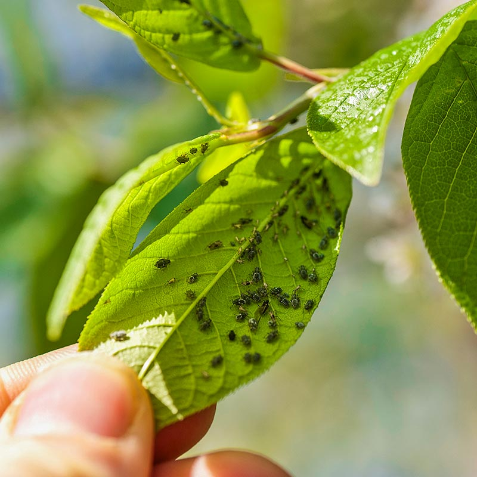

## Bt Corn Controversy

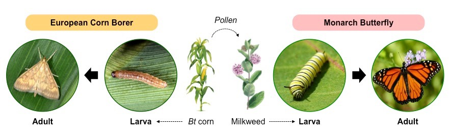

## The Promise of Golden Rice

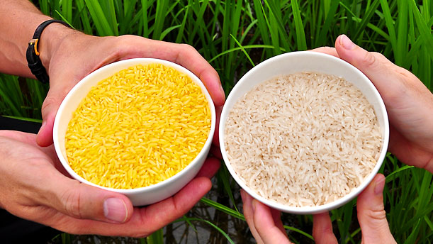

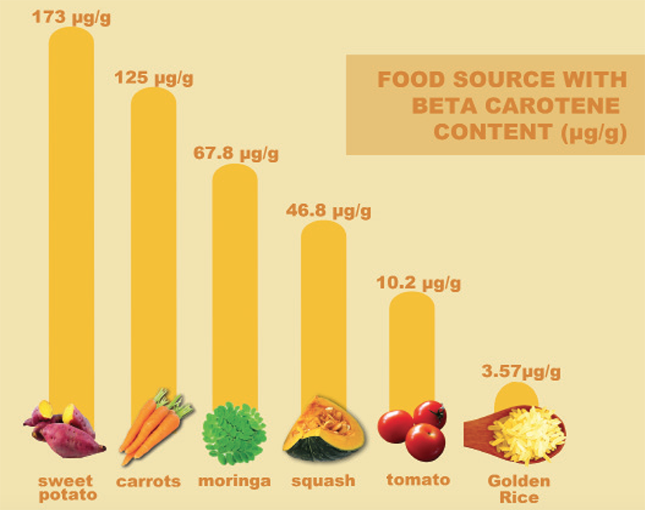

## Other GM Foods

**Soybean that produces less unsaturated fats (cholesterol)**

**Bananas with enhanced Vitamin A and iron**

**Granny Smith and Golden Delicious apples that do not brown when cut**

**Potatoes that produce low acrylmaide (cancer causing in rats) when fried**

**Alfalfa with lower lignin; easier to digest as animal feed**

**Corn that is drought-resistant (approved in 2011)**

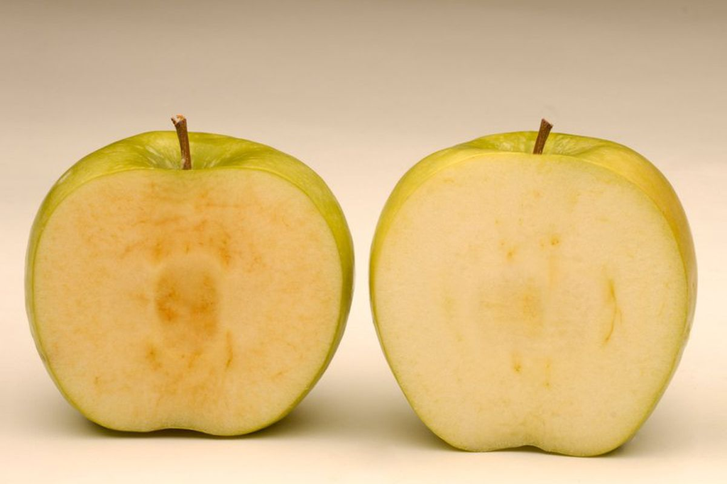

## Case study: Disease resistance

- **Viral genes have been inserted into various plants**
  - insert a fragment of the virus’s genome
  - plant’s immune machinery “patrols” for matching viral RNA.
- **Stone fruits are susceptible to plum pox virus**
  - 2010 USDA approved transgenic resistant plum
- **Blight resistant potatoes to Phytophtora now developed**
  - genes from S. American variety into red skin taters
- **Research ongoing to engineer blight resistance in wheat**

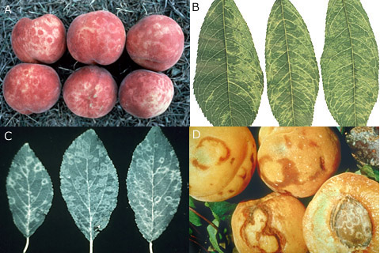

## GM Plants for Bioremediation

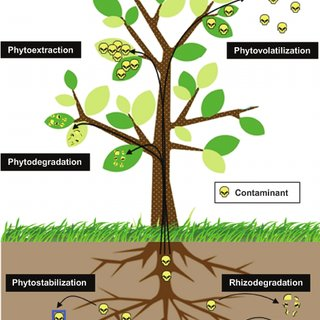

- **Plants engineered to accumulate heavy metals**
  - or breakdown various toxic compounds
- **Tobacco, birch, poplar, rice, Indian mustard**
- **None are approved but could process pollutants 100x faster than *regular* plants**

## Frost resistant *Eucalyptus* for paper, pulp and biofuels

[figure not shown]

## Regulation and Saftey concerns

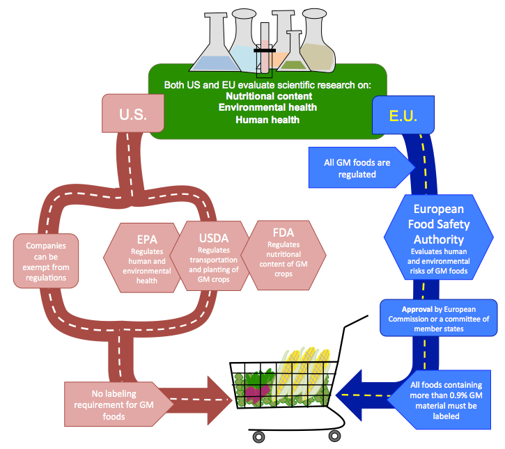

- **USDA, EPA and FDA involved in approval of GM crops**
  - transgenic plants with Bt must be approved by EPA
- **Is GM technology just an extension of traditional selection?**
- **Do we really know the impacts of transferring genes?**
  - some countries only use GM crops for animal feed
- **Could the altered organism pass genes to the wild?**
- **What happens when weeds become resistant to glyphosate?**
  - 59 already have

## Gene Editing: CRISPR/Cas9

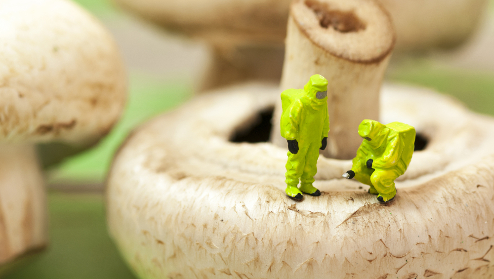

**Consumer gene-edited foods are on shelves: Japan’s high-GABA tomato was the first CRISPR food sold to the public (2021), showing a path for nutrition-oriented edits**

**Disease-resistant citrus moves forward in the U.S.: USDA said a CRISPR-edited orange with tolerance to citrus greening (HLB) isn’t subject to biotech regs—clearing the way for commercialization**

**Climate-smart edits: Tweaking stomatal density preserves photosynthesis while improving drought water-use efficiency in rice**

## Cons of genetic engineering

- **Herbicide-resistance or insect-resistance genes could spread**
  - from engineered crops to wild relatives
  - create weeds that are difficult to control
- **Does the USDA require sufficient precautions to prevent the spread of genes from engineered plants to their wild relatives?**
- **Bioengineered products could wipe out the major exports of developing nations**
  - bacterium under development to produces vanilla flavoring
  - could eliminate markets for Madagascar vanilla beans
- **Biological control may solve the problem, cheaper and more effectively, as shown with the work on the cassava mealybug by Dr. Hans Herren, winner of the 1995 World Food Prize**